# Risk Factor Analysis

## Outcome Variable

**Outcome Variable:** sstunted

## Predictor Variables

**Intervention Variable:** mhtcm

**Adjustment Set:**

- arm
- W_mage
- meducyrs
- feducyrs
- single
- delta_W_mage
- delta_meducyrs
- delta_feducyrs
- delta_single

## Stratifying Variables

The analysis was stratified on these variable(s):

- agecat
- studyid
- country

## Data Summary

| agecat | studyid | country | mhtcm | sstunted | n_cell | n |
| --- | --- | --- | --- | --- | --- | --- |
| Birth | ki0047075b-MAL-ED | BANGLADESH | >=155 cm | 0 | 24 | 246 |
| Birth | ki0047075b-MAL-ED | BANGLADESH | >=155 cm | 1 | 1 | 246 |
| Birth | ki0047075b-MAL-ED | BANGLADESH | <151 cm | 0 | 150 | 246 |
| Birth | ki0047075b-MAL-ED | BANGLADESH | <151 cm | 1 | 6 | 246 |
| Birth | ki0047075b-MAL-ED | BANGLADESH | [151-155) cm | 0 | 65 | 246 |
| Birth | ki0047075b-MAL-ED | BANGLADESH | [151-155) cm | 1 | 0 | 246 |
| Birth | ki0047075b-MAL-ED | BRAZIL | >=155 cm | 0 | 104 | 184 |
| Birth | ki0047075b-MAL-ED | BRAZIL | >=155 cm | 1 | 3 | 184 |
| Birth | ki0047075b-MAL-ED | BRAZIL | <151 cm | 0 | 46 | 184 |
| Birth | ki0047075b-MAL-ED | BRAZIL | <151 cm | 1 | 3 | 184 |
| Birth | ki0047075b-MAL-ED | BRAZIL | [151-155) cm | 0 | 26 | 184 |
| Birth | ki0047075b-MAL-ED | BRAZIL | [151-155) cm | 1 | 2 | 184 |
| Birth | ki0047075b-MAL-ED | INDIA | >=155 cm | 0 | 45 | 198 |
| Birth | ki0047075b-MAL-ED | INDIA | >=155 cm | 1 | 1 | 198 |
| Birth | ki0047075b-MAL-ED | INDIA | <151 cm | 0 | 91 | 198 |
| Birth | ki0047075b-MAL-ED | INDIA | <151 cm | 1 | 4 | 198 |
| Birth | ki0047075b-MAL-ED | INDIA | [151-155) cm | 0 | 55 | 198 |
| Birth | ki0047075b-MAL-ED | INDIA | [151-155) cm | 1 | 2 | 198 |
| Birth | ki0047075b-MAL-ED | NEPAL | >=155 cm | 0 | 27 | 172 |
| Birth | ki0047075b-MAL-ED | NEPAL | >=155 cm | 1 | 0 | 172 |
| Birth | ki0047075b-MAL-ED | NEPAL | <151 cm | 0 | 93 | 172 |
| Birth | ki0047075b-MAL-ED | NEPAL | <151 cm | 1 | 3 | 172 |
| Birth | ki0047075b-MAL-ED | NEPAL | [151-155) cm | 0 | 46 | 172 |
| Birth | ki0047075b-MAL-ED | NEPAL | [151-155) cm | 1 | 3 | 172 |
| Birth | ki0047075b-MAL-ED | PERU | >=155 cm | 0 | 57 | 276 |
| Birth | ki0047075b-MAL-ED | PERU | >=155 cm | 1 | 1 | 276 |
| Birth | ki0047075b-MAL-ED | PERU | <151 cm | 0 | 155 | 276 |
| Birth | ki0047075b-MAL-ED | PERU | <151 cm | 1 | 6 | 276 |
| Birth | ki0047075b-MAL-ED | PERU | [151-155) cm | 0 | 57 | 276 |
| Birth | ki0047075b-MAL-ED | PERU | [151-155) cm | 1 | 0 | 276 |

[output cut: 318 more lines]

The following strata were considered:

- agecat: 24 months, studyid: ki0047075b-MAL-ED, country: BANGLADESH
- agecat: 24 months, studyid: ki0047075b-MAL-ED, country: BRAZIL
- agecat: 24 months, studyid: ki0047075b-MAL-ED, country: INDIA
- agecat: 24 months, studyid: ki0047075b-MAL-ED, country: NEPAL
- agecat: 24 months, studyid: ki0047075b-MAL-ED, country: PERU
- agecat: 24 months, studyid: ki0047075b-MAL-ED, country: SOUTH AFRICA
- agecat: 24 months, studyid: ki0047075b-MAL-ED, country: TANZANIA, UNITED REPUBLIC OF
- agecat: 24 months, studyid: ki1017093-NIH-Birth, country: BANGLADESH
- agecat: 24 months, studyid: ki1017093b-PROVIDE, country: BANGLADESH
- agecat: 24 months, studyid: ki1017093c-NIH-Crypto, country: BANGLADESH
- agecat: 24 months, studyid: ki1066203-TanzaniaChild2, country: TANZANIA, UNITED REPUBLIC OF
- agecat: 24 months, studyid: ki1101329-Keneba, country: GAMBIA
- agecat: 24 months, studyid: ki1119695-PROBIT, country: BELARUS
- agecat: 24 months, studyid: ki1126311-ZVITAMBO, country: ZIMBABWE
- agecat: 24 months, studyid: ki1135781-COHORTS, country: GUATEMALA
- agecat: 24 months, studyid: ki1135781-COHORTS, country: INDIA
- agecat: 24 months, studyid: ki1135781-COHORTS, country: PHILIPPINES
- agecat: 24 months, studyid: ki1148112-LCNI-5, country: MALAWI
- agecat: 24 months, studyid: kiGH5241-JiVitA-3, country: BANGLADESH
- agecat: 6 months, studyid: ki0047075b-MAL-ED, country: BANGLADESH
- agecat: 6 months, studyid: ki0047075b-MAL-ED, country: BRAZIL
- agecat: 6 months, studyid: ki0047075b-MAL-ED, country: INDIA
- agecat: 6 months, studyid: ki0047075b-MAL-ED, country: NEPAL
- agecat: 6 months, studyid: ki0047075b-MAL-ED, country: PERU
- agecat: 6 months, studyid: ki0047075b-MAL-ED, country: SOUTH AFRICA
- agecat: 6 months, studyid: ki0047075b-MAL-ED, country: TANZANIA, UNITED REPUBLIC OF
- agecat: 6 months, studyid: ki1000304b-SAS-CompFeed, country: INDIA
- agecat: 6 months, studyid: ki1000304b-SAS-FoodSuppl, country: INDIA
- agecat: 6 months, studyid: ki1017093-NIH-Birth, country: BANGLADESH
- agecat: 6 months, studyid: ki1017093b-PROVIDE, country: BANGLADESH
- agecat: 6 months, studyid: ki1017093c-NIH-Crypto, country: BANGLADESH
- agecat: 6 months, studyid: ki1066203-TanzaniaChild2, country: TANZANIA, UNITED REPUBLIC OF
- agecat: 6 months, studyid: ki1101329-Keneba, country: GAMBIA
- agecat: 6 months, studyid: ki1112895-Guatemala BSC, country: GUATEMALA
- agecat: 6 months, studyid: ki1119695-PROBIT, country: BELARUS
- agecat: 6 months, studyid: ki1126311-ZVITAMBO, country: ZIMBABWE
- agecat: 6 months, studyid: ki1135781-COHORTS, country: GUATEMALA
- agecat: 6 months, studyid: ki1135781-COHORTS, country: INDIA
- agecat: 6 months, studyid: ki1135781-COHORTS, country: PHILIPPINES
- agecat: 6 months, studyid: ki1148112-LCNI-5, country: MALAWI
- agecat: 6 months, studyid: kiGH5241-JiVitA-3, country: BANGLADESH
- agecat: Birth, studyid: ki0047075b-MAL-ED, country: BANGLADESH
- agecat: Birth, studyid: ki0047075b-MAL-ED, country: BRAZIL
- agecat: Birth, studyid: ki0047075b-MAL-ED, country: INDIA
- agecat: Birth, studyid: ki0047075b-MAL-ED, country: NEPAL
- agecat: Birth, studyid: ki0047075b-MAL-ED, country: PERU
- agecat: Birth, studyid: ki0047075b-MAL-ED, country: SOUTH AFRICA
- agecat: Birth, studyid: ki0047075b-MAL-ED, country: TANZANIA, UNITED REPUBLIC OF
- agecat: Birth, studyid: ki1000304b-SAS-CompFeed, country: INDIA
- agecat: Birth, studyid: ki1017093-NIH-Birth, country: BANGLADESH
- agecat: Birth, studyid: ki1017093c-NIH-Crypto, country: BANGLADESH
- agecat: Birth, studyid: ki1101329-Keneba, country: GAMBIA
- agecat: Birth, studyid: ki1119695-PROBIT, country: BELARUS
- agecat: Birth, studyid: ki1126311-ZVITAMBO, country: ZIMBABWE
- agecat: Birth, studyid: ki1135781-COHORTS, country: GUATEMALA
- agecat: Birth, studyid: ki1135781-COHORTS, country: INDIA
- agecat: Birth, studyid: ki1135781-COHORTS, country: PHILIPPINES
- agecat: Birth, studyid: kiGH5241-JiVitA-3, country: BANGLADESH

### Dropped Strata

Some strata were dropped due to rare outcomes:

- agecat: Birth, studyid: ki0047075b-MAL-ED, country: BANGLADESH
- agecat: Birth, studyid: ki0047075b-MAL-ED, country: BRAZIL
- agecat: Birth, studyid: ki0047075b-MAL-ED, country: INDIA
- agecat: Birth, studyid: ki0047075b-MAL-ED, country: NEPAL
- agecat: Birth, studyid: ki0047075b-MAL-ED, country: PERU
- agecat: Birth, studyid: ki0047075b-MAL-ED, country: SOUTH AFRICA
- agecat: Birth, studyid: ki0047075b-MAL-ED, country: TANZANIA, UNITED REPUBLIC OF
- agecat: Birth, studyid: ki1000304b-SAS-CompFeed, country: INDIA
- agecat: Birth, studyid: ki1017093-NIH-Birth, country: BANGLADESH
- agecat: Birth, studyid: ki1017093c-NIH-Crypto, country: BANGLADESH
- agecat: Birth, studyid: ki1101329-Keneba, country: GAMBIA
- agecat: Birth, studyid: ki1119695-PROBIT, country: BELARUS
- agecat: Birth, studyid: ki1135781-COHORTS, country: GUATEMALA
- agecat: Birth, studyid: ki1135781-COHORTS, country: PHILIPPINES
- agecat: 6 months, studyid: ki0047075b-MAL-ED, country: BANGLADESH
- agecat: 6 months, studyid: ki0047075b-MAL-ED, country: BRAZIL
- agecat: 6 months, studyid: ki0047075b-MAL-ED, country: INDIA
- agecat: 6 months, studyid: ki0047075b-MAL-ED, country: NEPAL
- agecat: 6 months, studyid: ki0047075b-MAL-ED, country: PERU
- agecat: 6 months, studyid: ki0047075b-MAL-ED, country: SOUTH AFRICA
- agecat: 6 months, studyid: ki0047075b-MAL-ED, country: TANZANIA, UNITED REPUBLIC OF
- agecat: 6 months, studyid: ki1000304b-SAS-FoodSuppl, country: INDIA
- agecat: 6 months, studyid: ki1017093-NIH-Birth, country: BANGLADESH
- agecat: 6 months, studyid: ki1017093b-PROVIDE, country: BANGLADESH
- agecat: 6 months, studyid: ki1017093c-NIH-Crypto, country: BANGLADESH
- agecat: 6 months, studyid: ki1112895-Guatemala BSC, country: GUATEMALA
- agecat: 24 months, studyid: ki0047075b-MAL-ED, country: BANGLADESH
- agecat: 24 months, studyid: ki0047075b-MAL-ED, country: BRAZIL
- agecat: 24 months, studyid: ki0047075b-MAL-ED, country: INDIA
- agecat: 24 months, studyid: ki0047075b-MAL-ED, country: NEPAL
- agecat: 24 months, studyid: ki0047075b-MAL-ED, country: PERU
- agecat: 24 months, studyid: ki0047075b-MAL-ED, country: SOUTH AFRICA
- agecat: 24 months, studyid: ki1017093b-PROVIDE, country: BANGLADESH
- agecat: 24 months, studyid: ki1017093c-NIH-Crypto, country: BANGLADESH
- agecat: 24 months, studyid: ki1066203-TanzaniaChild2, country: TANZANIA, UNITED REPUBLIC OF
- agecat: 24 months, studyid: ki1119695-PROBIT, country: BELARUS

## Methods Detail

We’re interested in the causal parameters $E[Y_a]$ for all values of $a \in \mathcal{A}$. These parameters represent the mean outcome if, possibly contrary to fact, we intervened to set all units to have $A=a$. Under the randomization and positivity assumptions, these are identified by the statistical parameters $\psi_a=E_W[E_{Y|A,W}(Y|A=a,W)]$. In addition, we’re interested in the mean of $Y$, $E[Y]$ under no intervention (the observed mean). We will estimate these parameters by using SuperLearner to fit the relevant likelihood factors – $E_{Y|A,W}(Y|A=a,W)$ and $p(A=a|W)$, and then updating our likelihood fit using a joint TMLE.

For unadjusted analyses ($W=\{\}$), initial likelihoods were estimated using Lrnr_glm to estimate the simple $E(Y|A)$ and Lrnr_mean to estimate $p(A)$. For adjusted analyses, a small library containing Lrnr_glmnet, Lrnr_xgboost, and Lrnr_mean was used.

Having estimated these parameters, we will then use the delta method to estimate relative risks and attributable risks relative to a prespecified baseline level of $A$.

# Results Detail

## Results Plots

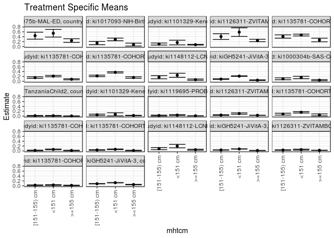

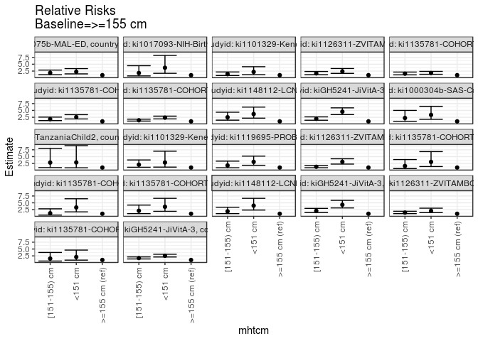

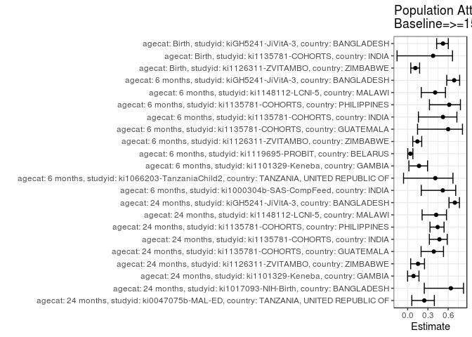

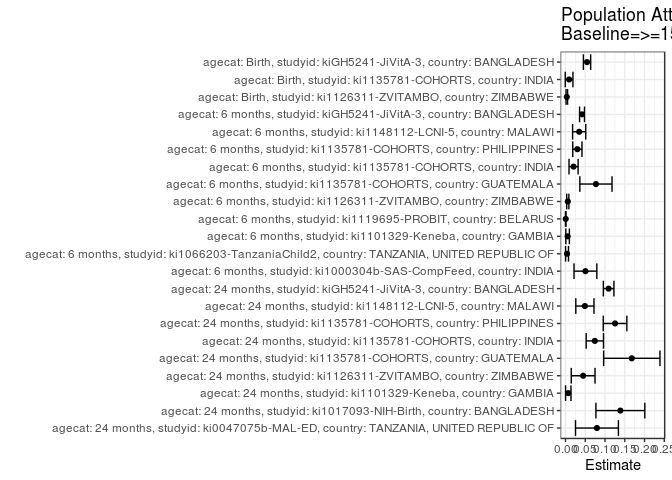

## Results Table

### Parameter: TSM

| agecat | studyid | country | intervention_level | baseline_level | estimate | ci_lower | ci_upper |
| --- | --- | --- | --- | --- | --- | --- | --- |
| Birth | ki1126311-ZVITAMBO | ZIMBABWE | >=155 cm | NA | 0.0259301 | 0.0223790 | 0.0294812 |
| Birth | ki1126311-ZVITAMBO | ZIMBABWE | <151 cm | NA | 0.0538060 | 0.0344839 | 0.0731282 |
| Birth | ki1126311-ZVITAMBO | ZIMBABWE | [151-155) cm | NA | 0.0368017 | 0.0269204 | 0.0466831 |
| Birth | ki1135781-COHORTS | INDIA | >=155 cm | NA | 0.0150943 | 0.0047110 | 0.0254777 |
| Birth | ki1135781-COHORTS | INDIA | <151 cm | NA | 0.0314548 | 0.0190665 | 0.0438431 |
| Birth | ki1135781-COHORTS | INDIA | [151-155) cm | NA | 0.0228690 | 0.0095062 | 0.0362318 |
| Birth | kiGH5241-JiVitA-3 | BANGLADESH | >=155 cm | NA | 0.0495426 | 0.0402332 | 0.0588519 |
| Birth | kiGH5241-JiVitA-3 | BANGLADESH | <151 cm | NA | 0.1258157 | 0.1193095 | 0.1323220 |
| Birth | kiGH5241-JiVitA-3 | BANGLADESH | [151-155) cm | NA | 0.0843651 | 0.0760284 | 0.0927018 |
| 6 months | ki1000304b-SAS-CompFeed | INDIA | >=155 cm | NA | 0.0464343 | 0.0225691 | 0.0702995 |
| 6 months | ki1000304b-SAS-CompFeed | INDIA | <151 cm | NA | 0.1565884 | 0.1066132 | 0.2065635 |
| 6 months | ki1000304b-SAS-CompFeed | INDIA | [151-155) cm | NA | 0.1036995 | 0.0647164 | 0.1426827 |
| 6 months | ki1066203-TanzaniaChild2 | TANZANIA, UNITED REPUBLIC OF | >=155 cm | NA | 0.0056180 | 0.0014669 | 0.0097691 |
| 6 months | ki1066203-TanzaniaChild2 | TANZANIA, UNITED REPUBLIC OF | <151 cm | NA | 0.0161812 | 0.0021097 | 0.0302527 |
| 6 months | ki1066203-TanzaniaChild2 | TANZANIA, UNITED REPUBLIC OF | [151-155) cm | NA | 0.0158730 | 0.0042051 | 0.0275409 |
| 6 months | ki1101329-Keneba | GAMBIA | >=155 cm | NA | 0.0261480 | 0.0182474 | 0.0340485 |
| 6 months | ki1101329-Keneba | GAMBIA | <151 cm | NA | 0.0746269 | 0.0116860 | 0.1375677 |
| 6 months | ki1101329-Keneba | GAMBIA | [151-155) cm | NA | 0.0537190 | 0.0253052 | 0.0821329 |
| 6 months | ki1119695-PROBIT | BELARUS | >=155 cm | NA | 0.0134046 | 0.0088341 | 0.0179751 |
| 6 months | ki1119695-PROBIT | BELARUS | <151 cm | NA | 0.0413223 | 0.0236142 | 0.0590305 |
| 6 months | ki1119695-PROBIT | BELARUS | [151-155) cm | NA | 0.0237467 | 0.0061571 | 0.0413363 |
| 6 months | ki1126311-ZVITAMBO | ZIMBABWE | >=155 cm | NA | 0.0342093 | 0.0294786 | 0.0389400 |
| 6 months | ki1126311-ZVITAMBO | ZIMBABWE | <151 cm | NA | 0.1061074 | 0.0768480 | 0.1353669 |
| 6 months | ki1126311-ZVITAMBO | ZIMBABWE | [151-155) cm | NA | 0.0440435 | 0.0314419 | 0.0566452 |
| 6 months | ki1135781-COHORTS | GUATEMALA | >=155 cm | NA | 0.0512821 | 0.0112934 | 0.0912707 |
| 6 months | ki1135781-COHORTS | GUATEMALA | <151 cm | NA | 0.1573927 | 0.1289181 | 0.1858673 |
| 6 months | ki1135781-COHORTS | GUATEMALA | [151-155) cm | NA | 0.0812183 | 0.0430521 | 0.1193844 |
| 6 months | ki1135781-COHORTS | INDIA | >=155 cm | NA | 0.0185924 | 0.0071805 | 0.0300043 |
| 6 months | ki1135781-COHORTS | INDIA | <151 cm | NA | 0.0615474 | 0.0445439 | 0.0785509 |
| 6 months | ki1135781-COHORTS | INDIA | [151-155) cm | NA | 0.0221931 | 0.0089782 | 0.0354081 |
| 6 months | ki1135781-COHORTS | PHILIPPINES | >=155 cm | NA | 0.0187190 | 0.0076202 | 0.0298178 |
| 6 months | ki1135781-COHORTS | PHILIPPINES | <151 cm | NA | 0.0665193 | 0.0533116 | 0.0797269 |
| 6 months | ki1135781-COHORTS | PHILIPPINES | [151-155) cm | NA | 0.0393443 | 0.0256508 | 0.0530377 |
| 6 months | ki1148112-LCNI-5 | MALAWI | >=155 cm | NA | 0.0503202 | 0.0312891 | 0.0693512 |
| 6 months | ki1148112-LCNI-5 | MALAWI | <151 cm | NA | 0.1992989 | 0.1287675 | 0.2698304 |
| 6 months | ki1148112-LCNI-5 | MALAWI | [151-155) cm | NA | 0.0954494 | 0.0532824 | 0.1376164 |
| 6 months | kiGH5241-JiVitA-3 | BANGLADESH | >=155 cm | NA | 0.0188424 | 0.0129481 | 0.0247366 |
| 6 months | kiGH5241-JiVitA-3 | BANGLADESH | <151 cm | NA | 0.0809765 | 0.0752501 | 0.0867030 |
| 6 months | kiGH5241-JiVitA-3 | BANGLADESH | [151-155) cm | NA | 0.0392462 | 0.0332110 | 0.0452815 |
| 24 months | ki0047075b-MAL-ED | TANZANIA, UNITED REPUBLIC OF | >=155 cm | NA | 0.2428039 | 0.1684414 | 0.3171664 |
| 24 months | ki0047075b-MAL-ED | TANZANIA, UNITED REPUBLIC OF | <151 cm | NA | 0.5434976 | 0.3871999 | 0.6997952 |
| 24 months | ki0047075b-MAL-ED | TANZANIA, UNITED REPUBLIC OF | [151-155) cm | NA | 0.4441330 | 0.3004157 | 0.5878502 |
| 24 months | ki1017093-NIH-Birth | BANGLADESH | >=155 cm | NA | 0.0779221 | 0.0179811 | 0.1378630 |
| 24 months | ki1017093-NIH-Birth | BANGLADESH | <151 cm | NA | 0.2896825 | 0.2336111 | 0.3457540 |
| 24 months | ki1017093-NIH-Birth | BANGLADESH | [151-155) cm | NA | 0.1400000 | 0.0719124 | 0.2080876 |
| 24 months | ki1101329-Keneba | GAMBIA | >=155 cm | NA | 0.0735026 | 0.0595319 | 0.0874734 |
| 24 months | ki1101329-Keneba | GAMBIA | <151 cm | NA | 0.1615373 | 0.0657557 | 0.2573189 |
| 24 months | ki1101329-Keneba | GAMBIA | [151-155) cm | NA | 0.1009832 | 0.0589736 | 0.1429928 |
| 24 months | ki1126311-ZVITAMBO | ZIMBABWE | >=155 cm | NA | 0.2463490 | 0.1957454 | 0.2969525 |
| 24 months | ki1126311-ZVITAMBO | ZIMBABWE | <151 cm | NA | 0.5892689 | 0.4137207 | 0.7648172 |
| 24 months | ki1126311-ZVITAMBO | ZIMBABWE | [151-155) cm | NA | 0.4071248 | 0.2901187 | 0.5241310 |
| 24 months | ki1135781-COHORTS | GUATEMALA | >=155 cm | NA | 0.2654864 | 0.1906081 | 0.3403648 |
| 24 months | ki1135781-COHORTS | GUATEMALA | <151 cm | NA | 0.4706823 | 0.4326155 | 0.5087491 |
| 24 months | ki1135781-COHORTS | GUATEMALA | [151-155) cm | NA | 0.4090461 | 0.3420084 | 0.4760839 |
| 24 months | ki1135781-COHORTS | INDIA | >=155 cm | NA | 0.0835153 | 0.0608390 | 0.1061916 |
| 24 months | ki1135781-COHORTS | INDIA | <151 cm | NA | 0.2130172 | 0.1841941 | 0.2418404 |
| 24 months | ki1135781-COHORTS | INDIA | [151-155) cm | NA | 0.1516097 | 0.1194081 | 0.1838113 |
| 24 months | ki1135781-COHORTS | PHILIPPINES | >=155 cm | NA | 0.1563702 | 0.1249654 | 0.1877749 |
| 24 months | ki1135781-COHORTS | PHILIPPINES | <151 cm | NA | 0.3677825 | 0.3408743 | 0.3946908 |
| 24 months | ki1135781-COHORTS | PHILIPPINES | [151-155) cm | NA | 0.2210267 | 0.1901727 | 0.2518806 |
| 24 months | ki1148112-LCNI-5 | MALAWI | >=155 cm | NA | 0.0670523 | 0.0408846 | 0.0932200 |
| 24 months | ki1148112-LCNI-5 | MALAWI | <151 cm | NA | 0.2468459 | 0.1608557 | 0.3328362 |
| 24 months | ki1148112-LCNI-5 | MALAWI | [151-155) cm | NA | 0.1678743 | 0.1030415 | 0.2327071 |
| 24 months | kiGH5241-JiVitA-3 | BANGLADESH | >=155 cm | NA | 0.0467600 | 0.0345583 | 0.0589617 |
| 24 months | kiGH5241-JiVitA-3 | BANGLADESH | <151 cm | NA | 0.2127146 | 0.2002668 | 0.2251625 |
| 24 months | kiGH5241-JiVitA-3 | BANGLADESH | [151-155) cm | NA | 0.0904895 | 0.0756039 | 0.1053751 |

### Parameter: E(Y)

| agecat | studyid | country | intervention_level | baseline_level | estimate | ci_lower | ci_upper |
| --- | --- | --- | --- | --- | --- | --- | --- |
| Birth | ki1126311-ZVITAMBO | ZIMBABWE | NA | NA | 0.0292749 | 0.0259142 | 0.0326355 |
| Birth | ki1135781-COHORTS | INDIA | NA | NA | 0.0242390 | 0.0170805 | 0.0313975 |
| Birth | kiGH5241-JiVitA-3 | BANGLADESH | NA | NA | 0.1040643 | 0.0993882 | 0.1087404 |
| 6 months | ki1000304b-SAS-CompFeed | INDIA | NA | NA | 0.0969055 | 0.0737418 | 0.1200693 |
| 6 months | ki1066203-TanzaniaChild2 | TANZANIA, UNITED REPUBLIC OF | NA | NA | 0.0095190 | 0.0052582 | 0.0137799 |
| 6 months | ki1101329-Keneba | GAMBIA | NA | NA | 0.0314331 | 0.0235374 | 0.0393288 |
| 6 months | ki1119695-PROBIT | BELARUS | NA | NA | 0.0139646 | 0.0092016 | 0.0187275 |
| 6 months | ki1126311-ZVITAMBO | ZIMBABWE | NA | NA | 0.0399944 | 0.0354446 | 0.0445442 |
| 6 months | ki1135781-COHORTS | GUATEMALA | NA | NA | 0.1283139 | 0.1069569 | 0.1496709 |
| 6 months | ki1135781-COHORTS | INDIA | NA | NA | 0.0390324 | 0.0301298 | 0.0479351 |
| 6 months | ki1135781-COHORTS | PHILIPPINES | NA | NA | 0.0487445 | 0.0406327 | 0.0568562 |
| 6 months | ki1148112-LCNI-5 | MALAWI | NA | NA | 0.0849282 | 0.0660197 | 0.1038368 |
| 6 months | kiGH5241-JiVitA-3 | BANGLADESH | NA | NA | 0.0606766 | 0.0568171 | 0.0645361 |
| 24 months | ki0047075b-MAL-ED | TANZANIA, UNITED REPUBLIC OF | NA | NA | 0.3224299 | 0.2596598 | 0.3852000 |
| 24 months | ki1017093-NIH-Birth | BANGLADESH | NA | NA | 0.2167832 | 0.1777459 | 0.2558205 |
| 24 months | ki1101329-Keneba | GAMBIA | NA | NA | 0.0805243 | 0.0671957 | 0.0938530 |
| 24 months | ki1126311-ZVITAMBO | ZIMBABWE | NA | NA | 0.2910053 | 0.2451542 | 0.3368563 |
| 24 months | ki1135781-COHORTS | GUATEMALA | NA | NA | 0.4332999 | 0.4025255 | 0.4640743 |
| 24 months | ki1135781-COHORTS | INDIA | NA | NA | 0.1577790 | 0.1410223 | 0.1745357 |
| 24 months | ki1135781-COHORTS | PHILIPPINES | NA | NA | 0.2817996 | 0.2639639 | 0.2996353 |
| 24 months | ki1148112-LCNI-5 | MALAWI | NA | NA | 0.1161179 | 0.0899551 | 0.1422806 |
| 24 months | kiGH5241-JiVitA-3 | BANGLADESH | NA | NA | 0.1559484 | 0.1471934 | 0.1647033 |

### Parameter: RR

| agecat | studyid | country | intervention_level | baseline_level | estimate | ci_lower | ci_upper |
| --- | --- | --- | --- | --- | --- | --- | --- |
| Birth | ki1126311-ZVITAMBO | ZIMBABWE | >=155 cm | >=155 cm | 1.000000 | 1.0000000 | 1.000000 |
| Birth | ki1126311-ZVITAMBO | ZIMBABWE | <151 cm | >=155 cm | 2.075041 | 1.4129053 | 3.047476 |
| Birth | ki1126311-ZVITAMBO | ZIMBABWE | [151-155) cm | >=155 cm | 1.419267 | 1.0498949 | 1.918591 |
| Birth | ki1135781-COHORTS | INDIA | >=155 cm | >=155 cm | 1.000000 | 1.0000000 | 1.000000 |
| Birth | ki1135781-COHORTS | INDIA | <151 cm | >=155 cm | 2.083879 | 0.9432426 | 4.603856 |
| Birth | ki1135781-COHORTS | INDIA | [151-155) cm | >=155 cm | 1.515073 | 0.6144022 | 3.736063 |
| Birth | kiGH5241-JiVitA-3 | BANGLADESH | >=155 cm | >=155 cm | 1.000000 | 1.0000000 | 1.000000 |
| Birth | kiGH5241-JiVitA-3 | BANGLADESH | <151 cm | >=155 cm | 2.539548 | 2.0903243 | 3.085313 |
| Birth | kiGH5241-JiVitA-3 | BANGLADESH | [151-155) cm | >=155 cm | 1.702881 | 1.3729388 | 2.112114 |
| 6 months | ki1000304b-SAS-CompFeed | INDIA | >=155 cm | >=155 cm | 1.000000 | 1.0000000 | 1.000000 |
| 6 months | ki1000304b-SAS-CompFeed | INDIA | <151 cm | >=155 cm | 3.372255 | 1.7497676 | 6.499208 |
| 6 months | ki1000304b-SAS-CompFeed | INDIA | [151-155) cm | >=155 cm | 2.233252 | 0.9965231 | 5.004817 |
| 6 months | ki1066203-TanzaniaChild2 | TANZANIA, UNITED REPUBLIC OF | >=155 cm | >=155 cm | 1.000000 | 1.0000000 | 1.000000 |
| 6 months | ki1066203-TanzaniaChild2 | TANZANIA, UNITED REPUBLIC OF | <151 cm | >=155 cm | 2.880259 | 0.9201086 | 9.016209 |
| 6 months | ki1066203-TanzaniaChild2 | TANZANIA, UNITED REPUBLIC OF | [151-155) cm | >=155 cm | 2.825397 | 0.9963933 | 8.011763 |
| 6 months | ki1101329-Keneba | GAMBIA | >=155 cm | >=155 cm | 1.000000 | 1.0000000 | 1.000000 |
| 6 months | ki1101329-Keneba | GAMBIA | <151 cm | >=155 cm | 2.854023 | 1.1651317 | 6.991008 |
| 6 months | ki1101329-Keneba | GAMBIA | [151-155) cm | >=155 cm | 2.054425 | 1.1172215 | 3.777819 |
| 6 months | ki1119695-PROBIT | BELARUS | >=155 cm | >=155 cm | 1.000000 | 1.0000000 | 1.000000 |
| 6 months | ki1119695-PROBIT | BELARUS | <151 cm | >=155 cm | 3.082694 | 1.8352787 | 5.177961 |
| 6 months | ki1119695-PROBIT | BELARUS | [151-155) cm | >=155 cm | 1.771532 | 0.9357442 | 3.353829 |
| 6 months | ki1126311-ZVITAMBO | ZIMBABWE | >=155 cm | >=155 cm | 1.000000 | 1.0000000 | 1.000000 |
| 6 months | ki1126311-ZVITAMBO | ZIMBABWE | <151 cm | >=155 cm | 3.101714 | 2.2784015 | 4.222536 |
| 6 months | ki1126311-ZVITAMBO | ZIMBABWE | [151-155) cm | >=155 cm | 1.287473 | 0.9369052 | 1.769215 |
| 6 months | ki1135781-COHORTS | GUATEMALA | >=155 cm | >=155 cm | 1.000000 | 1.0000000 | 1.000000 |
| 6 months | ki1135781-COHORTS | GUATEMALA | <151 cm | >=155 cm | 3.069157 | 1.3783850 | 6.833887 |
| 6 months | ki1135781-COHORTS | GUATEMALA | [151-155) cm | >=155 cm | 1.583756 | 0.6372270 | 3.936249 |
| 6 months | ki1135781-COHORTS | INDIA | >=155 cm | >=155 cm | 1.000000 | 1.0000000 | 1.000000 |
| 6 months | ki1135781-COHORTS | INDIA | <151 cm | >=155 cm | 3.310354 | 1.6884094 | 6.490396 |
| 6 months | ki1135781-COHORTS | INDIA | [151-155) cm | >=155 cm | 1.193667 | 0.5074675 | 2.807747 |
| 6 months | ki1135781-COHORTS | PHILIPPINES | >=155 cm | >=155 cm | 1.000000 | 1.0000000 | 1.000000 |
| 6 months | ki1135781-COHORTS | PHILIPPINES | <151 cm | >=155 cm | 3.553567 | 1.9018607 | 6.639729 |
| 6 months | ki1135781-COHORTS | PHILIPPINES | [151-155) cm | >=155 cm | 2.101834 | 1.0572808 | 4.178366 |
| 6 months | ki1148112-LCNI-5 | MALAWI | >=155 cm | >=155 cm | 1.000000 | 1.0000000 | 1.000000 |
| 6 months | ki1148112-LCNI-5 | MALAWI | <151 cm | >=155 cm | 3.960618 | 2.3591846 | 6.649116 |
| 6 months | ki1148112-LCNI-5 | MALAWI | [151-155) cm | >=155 cm | 1.896842 | 1.0612856 | 3.390238 |
| 6 months | kiGH5241-JiVitA-3 | BANGLADESH | >=155 cm | >=155 cm | 1.000000 | 1.0000000 | 1.000000 |
| 6 months | kiGH5241-JiVitA-3 | BANGLADESH | <151 cm | >=155 cm | 4.297580 | 3.1255038 | 5.909189 |
| 6 months | kiGH5241-JiVitA-3 | BANGLADESH | [151-155) cm | >=155 cm | 2.082873 | 1.4576474 | 2.976274 |
| 24 months | ki0047075b-MAL-ED | TANZANIA, UNITED REPUBLIC OF | >=155 cm | >=155 cm | 1.000000 | 1.0000000 | 1.000000 |
| 24 months | ki0047075b-MAL-ED | TANZANIA, UNITED REPUBLIC OF | <151 cm | >=155 cm | 2.238422 | 1.4717090 | 3.404568 |
| 24 months | ki0047075b-MAL-ED | TANZANIA, UNITED REPUBLIC OF | [151-155) cm | >=155 cm | 1.829184 | 1.1703971 | 2.858785 |
| 24 months | ki1017093-NIH-Birth | BANGLADESH | >=155 cm | >=155 cm | 1.000000 | 1.0000000 | 1.000000 |
| 24 months | ki1017093-NIH-Birth | BANGLADESH | <151 cm | >=155 cm | 3.717593 | 1.6817843 | 8.217757 |
| 24 months | ki1017093-NIH-Birth | BANGLADESH | [151-155) cm | >=155 cm | 1.796667 | 0.7231383 | 4.463892 |
| 24 months | ki1101329-Keneba | GAMBIA | >=155 cm | >=155 cm | 1.000000 | 1.0000000 | 1.000000 |
| 24 months | ki1101329-Keneba | GAMBIA | <151 cm | >=155 cm | 2.197708 | 1.1790800 | 4.096347 |
| 24 months | ki1101329-Keneba | GAMBIA | [151-155) cm | >=155 cm | 1.373873 | 0.8695362 | 2.170727 |
| 24 months | ki1126311-ZVITAMBO | ZIMBABWE | >=155 cm | >=155 cm | 1.000000 | 1.0000000 | 1.000000 |
| 24 months | ki1126311-ZVITAMBO | ZIMBABWE | <151 cm | >=155 cm | 2.392009 | 1.6631439 | 3.440296 |
| 24 months | ki1126311-ZVITAMBO | ZIMBABWE | [151-155) cm | >=155 cm | 1.652635 | 1.1601716 | 2.354136 |
| 24 months | ki1135781-COHORTS | GUATEMALA | >=155 cm | >=155 cm | 1.000000 | 1.0000000 | 1.000000 |
| 24 months | ki1135781-COHORTS | GUATEMALA | <151 cm | >=155 cm | 1.772905 | 1.3229058 | 2.375976 |
| 24 months | ki1135781-COHORTS | GUATEMALA | [151-155) cm | >=155 cm | 1.540742 | 1.1134633 | 2.131984 |
| 24 months | ki1135781-COHORTS | INDIA | >=155 cm | >=155 cm | 1.000000 | 1.0000000 | 1.000000 |
| 24 months | ki1135781-COHORTS | INDIA | <151 cm | >=155 cm | 2.550637 | 1.8840029 | 3.453153 |
| 24 months | ki1135781-COHORTS | INDIA | [151-155) cm | >=155 cm | 1.815352 | 1.2857084 | 2.563182 |
| 24 months | ki1135781-COHORTS | PHILIPPINES | >=155 cm | >=155 cm | 1.000000 | 1.0000000 | 1.000000 |
| 24 months | ki1135781-COHORTS | PHILIPPINES | <151 cm | >=155 cm | 2.351999 | 1.8992936 | 2.912609 |
| 24 months | ki1135781-COHORTS | PHILIPPINES | [151-155) cm | >=155 cm | 1.413484 | 1.1067625 | 1.805207 |
| 24 months | ki1148112-LCNI-5 | MALAWI | >=155 cm | >=155 cm | 1.000000 | 1.0000000 | 1.000000 |
| 24 months | ki1148112-LCNI-5 | MALAWI | <151 cm | >=155 cm | 3.681395 | 2.1807994 | 6.214542 |
| 24 months | ki1148112-LCNI-5 | MALAWI | [151-155) cm | >=155 cm | 2.503633 | 1.4426678 | 4.344851 |
| 24 months | kiGH5241-JiVitA-3 | BANGLADESH | >=155 cm | >=155 cm | 1.000000 | 1.0000000 | 1.000000 |
| 24 months | kiGH5241-JiVitA-3 | BANGLADESH | <151 cm | >=155 cm | 4.549071 | 3.4828680 | 5.941668 |
| 24 months | kiGH5241-JiVitA-3 | BANGLADESH | [151-155) cm | >=155 cm | 1.935189 | 1.4148261 | 2.646937 |

### Parameter: PAR

| agecat | studyid | country | intervention_level | baseline_level | estimate | ci_lower | ci_upper |
| --- | --- | --- | --- | --- | --- | --- | --- |
| Birth | ki1126311-ZVITAMBO | ZIMBABWE | >=155 cm | NA | 0.0033448 | 0.0013935 | 0.0052960 |
| Birth | ki1135781-COHORTS | INDIA | >=155 cm | NA | 0.0091447 | -0.0005835 | 0.0188728 |
| Birth | kiGH5241-JiVitA-3 | BANGLADESH | >=155 cm | NA | 0.0545217 | 0.0453464 | 0.0636970 |
| 6 months | ki1000304b-SAS-CompFeed | INDIA | >=155 cm | NA | 0.0504712 | 0.0216008 | 0.0793417 |
| 6 months | ki1066203-TanzaniaChild2 | TANZANIA, UNITED REPUBLIC OF | >=155 cm | NA | 0.0039011 | 0.0001764 | 0.0076257 |
| 6 months | ki1101329-Keneba | GAMBIA | >=155 cm | NA | 0.0052852 | 0.0007603 | 0.0098101 |
| 6 months | ki1119695-PROBIT | BELARUS | >=155 cm | NA | 0.0005599 | -0.0000136 | 0.0011335 |
| 6 months | ki1126311-ZVITAMBO | ZIMBABWE | >=155 cm | NA | 0.0057851 | 0.0030537 | 0.0085165 |
| 6 months | ki1135781-COHORTS | GUATEMALA | >=155 cm | NA | 0.0770318 | 0.0363083 | 0.1177554 |
| 6 months | ki1135781-COHORTS | INDIA | >=155 cm | NA | 0.0204400 | 0.0089331 | 0.0319470 |
| 6 months | ki1135781-COHORTS | PHILIPPINES | >=155 cm | NA | 0.0300255 | 0.0183558 | 0.0416951 |
| 6 months | ki1148112-LCNI-5 | MALAWI | >=155 cm | NA | 0.0346081 | 0.0179892 | 0.0512270 |
| 6 months | kiGH5241-JiVitA-3 | BANGLADESH | >=155 cm | NA | 0.0418342 | 0.0356220 | 0.0480464 |
| 24 months | ki0047075b-MAL-ED | TANZANIA, UNITED REPUBLIC OF | >=155 cm | NA | 0.0796260 | 0.0253328 | 0.1339192 |
| 24 months | ki1017093-NIH-Birth | BANGLADESH | >=155 cm | NA | 0.1388611 | 0.0769979 | 0.2007244 |
| 24 months | ki1101329-Keneba | GAMBIA | >=155 cm | NA | 0.0070217 | 0.0001682 | 0.0138752 |
| 24 months | ki1126311-ZVITAMBO | ZIMBABWE | >=155 cm | NA | 0.0446563 | 0.0146036 | 0.0747091 |
| 24 months | ki1135781-COHORTS | GUATEMALA | >=155 cm | NA | 0.1678135 | 0.0965165 | 0.2391104 |
| 24 months | ki1135781-COHORTS | INDIA | >=155 cm | NA | 0.0742637 | 0.0523300 | 0.0961974 |
| 24 months | ki1135781-COHORTS | PHILIPPINES | >=155 cm | NA | 0.1254294 | 0.0956021 | 0.1552567 |
| 24 months | ki1148112-LCNI-5 | MALAWI | >=155 cm | NA | 0.0490656 | 0.0260847 | 0.0720464 |
| 24 months | kiGH5241-JiVitA-3 | BANGLADESH | >=155 cm | NA | 0.1091883 | 0.0957997 | 0.1225770 |

### Parameter: PAF

| agecat | studyid | country | intervention_level | baseline_level | estimate | ci_lower | ci_upper |
| --- | --- | --- | --- | --- | --- | --- | --- |
| Birth | ki1126311-ZVITAMBO | ZIMBABWE | >=155 cm | NA | 0.1142535 | 0.0463356 | 0.1773344 |
| Birth | ki1135781-COHORTS | INDIA | >=155 cm | NA | 0.3772707 | -0.1575587 | 0.6649917 |
| Birth | kiGH5241-JiVitA-3 | BANGLADESH | >=155 cm | NA | 0.5239235 | 0.4297071 | 0.6025747 |
| 6 months | ki1000304b-SAS-CompFeed | INDIA | >=155 cm | NA | 0.5208290 | 0.2015670 | 0.7124307 |
| 6 months | ki1066203-TanzaniaChild2 | TANZANIA, UNITED REPUBLIC OF | >=155 cm | NA | 0.4098167 | -0.0610110 | 0.6717128 |
| 6 months | ki1101329-Keneba | GAMBIA | >=155 cm | NA | 0.1681403 | 0.0180716 | 0.2952740 |
| 6 months | ki1119695-PROBIT | BELARUS | >=155 cm | NA | 0.0400972 | 0.0014302 | 0.0772670 |
| 6 months | ki1126311-ZVITAMBO | ZIMBABWE | >=155 cm | NA | 0.1446479 | 0.0755783 | 0.2085570 |
| 6 months | ki1135781-COHORTS | GUATEMALA | >=155 cm | NA | 0.6003391 | 0.1466206 | 0.8128278 |
| 6 months | ki1135781-COHORTS | INDIA | >=155 cm | NA | 0.5236681 | 0.1594533 | 0.7300660 |
| 6 months | ki1135781-COHORTS | PHILIPPINES | >=155 cm | NA | 0.6159767 | 0.3230482 | 0.7821501 |
| 6 months | ki1148112-LCNI-5 | MALAWI | >=155 cm | NA | 0.4074978 | 0.2017810 | 0.5601974 |
| 6 months | kiGH5241-JiVitA-3 | BANGLADESH | >=155 cm | NA | 0.6894624 | 0.5792597 | 0.7708001 |
| 24 months | ki0047075b-MAL-ED | TANZANIA, UNITED REPUBLIC OF | >=155 cm | NA | 0.2469560 | 0.0616746 | 0.3956519 |
| 24 months | ki1017093-NIH-Birth | BANGLADESH | >=155 cm | NA | 0.6405530 | 0.2465165 | 0.8285269 |
| 24 months | ki1101329-Keneba | GAMBIA | >=155 cm | NA | 0.0872000 | -0.0007880 | 0.1674521 |
| 24 months | ki1126311-ZVITAMBO | ZIMBABWE | >=155 cm | NA | 0.1534554 | 0.0448361 | 0.2497227 |
| 24 months | ki1135781-COHORTS | GUATEMALA | >=155 cm | NA | 0.3872917 | 0.1990009 | 0.5313210 |
| 24 months | ki1135781-COHORTS | INDIA | >=155 cm | NA | 0.4706817 | 0.3221424 | 0.5866716 |
| 24 months | ki1135781-COHORTS | PHILIPPINES | >=155 cm | NA | 0.4451015 | 0.3310693 | 0.5396946 |
| 24 months | ki1148112-LCNI-5 | MALAWI | >=155 cm | NA | 0.4225497 | 0.2140425 | 0.5757419 |
| 24 months | kiGH5241-JiVitA-3 | BANGLADESH | >=155 cm | NA | 0.7001571 | 0.6131611 | 0.7675886 |